# Rob Gordon Rebalancing Tool

# 6 Portfolio Optimization

## 6.1 Create Time-Series Object for Optimization

```r
# convert to ts object
stock_returns <- mo_returns %>%
  # filter(symbol %in% c("SPY", "GLD", "QQQ", "DBC")) %>%
  spread(key = symbol, value = returns) %>%
  tk_xts(date_var = date) %>%
  na.omit()
```

## 6.2 Run Minimum Variance Optimization

- set objective: risk minimization (variance)
- contraint 1: invest all funds
- contrstaint 2: long only

```r
# Markowitz Optimization involves minimizing the risk(variance) of returns and maximizing returns.
# https://rdrr.io/cran/PortfolioAnalytics/f/inst/doc/ROI_vignette.pdf
library(PortfolioAnalytics)

# Loading all suggested packages to fix ROI issue
# list.of.packages <- c("foreach", "DEoptim", "iterators", "fGarch", "Rglpk", "quadprog", "ROI", "ROI.plugin.glpk", "ROI.plugin.quadprog", "ROI.plugin.symphony", "pso", "GenSA", "corpcor", "testthat", "nloptr", "MASS", "robustbase")
# new.packages <- list.of.packages[!(list.of.packages %in% installed.packages()[,"Package"])]
# if(length(new.packages)) install.packages(new.packages)

rm(portf_minvar)
# Create portfolio object
portf_minvar <- portfolio.spec(assets = colnames(stock_returns))
# portf_minvar <- portfolio.spec(assets = colnames(returns.portfolio))
# Add full investment constraint to the portfolio object
portf_minvar <- add.constraint(portfolio=portf_minvar, type="full_investment")
# Add objective to minimize variance
portf_minvar <- add.objective(portfolio=portf_minvar, type="risk", name="var")
# Add long only constraints
portf_minvar <- add.constraint(portfolio=portf_minvar, type="box", min=0, max=1)
 # Run the optimization
opt_gmv <- optimize.portfolio(R=stock_returns, portfolio=portf_minvar, optimize_method="ROI", trace=TRUE)
print(opt_gmv, digits = 5)
```

PortfolioAnalytics Optimization ***********************************

Call: optimize.portfolio(R = stock_returns, portfolio = portf_minvar, optimize_method = “ROI”, trace = TRUE)

Optimal Weights: DBC EEM EFA GLD IWM IYR QQQ SPY TLT 0.00000 0.00000 0.00000 0.48752 0.00000 0.00000 0.00000 0.13548 0.37700

Objective Measure: StdDev 0.012616

```r
#summary(opt_gmv)
print("Optimal Weights")
```

[1] “Optimal Weights”

```r
wts <- opt_gmv['weights'] %>% as.data.frame() %>%
  mutate(.,symbol = rownames(.)) %>% select(symbol, weights)
wts
```

| symbol | weights |
| --- | --- |
| DBC | 0.0000000 |
| EEM | 0.0000000 |
| EFA | 0.0000000 |
| GLD | 0.4875174 |
| IWM | 0.0000000 |
| IYR | 0.0000000 |
| QQQ | 0.0000000 |
| SPY | 0.1354820 |
| TLT | 0.3770005 |

# 7 Visualize Portfolio Optimization

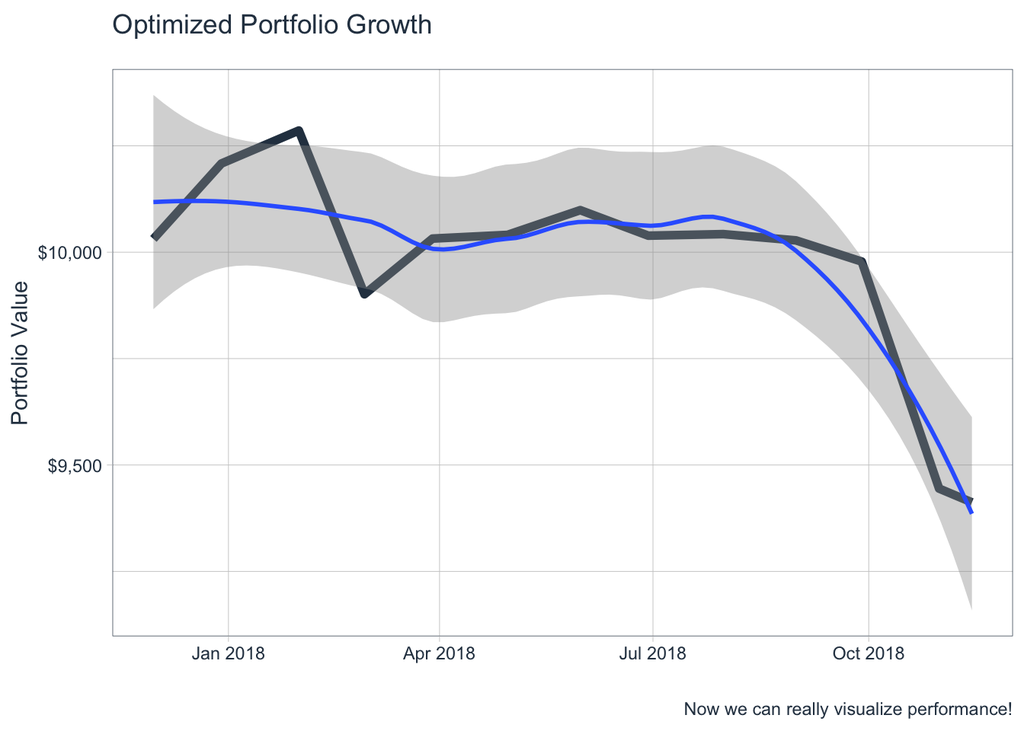

# 8 BACKTEST

## 8.1 Get Historical Stock Returns (3 Years)

```r
hist_returns <- tq_get(stocks
                     , get  = "stock.prices"
                     , from = Sys.Date() - months(36)
                     , to = Sys.Date()) %>%
  group_by(symbol) %>%
  tq_transmute(select = adjusted,
                 mutate_fun = periodReturn,
                 period     = "monthly",
                 col_rename = "returns") %>%
  spread(key = symbol, value = returns) %>%
  tk_xts(date_var = date) %>%
  na.omit()
```

## 8.2 Perform Backtest

```r
# https://rdrr.io/cran/PortfolioAnalytics/f/inst/doc/ROI_vignette.pdf
bt_gmv <- optimize.portfolio.rebalancing(R=hist_returns, portfolio=portf_minvar,
                                         optimize_method="ROI",
                                         rebalance_on="months",
                                         training_period=36-6)

print(bt_gmv)
```

PortfolioAnalytics Optimization with Rebalancing **************************************************

Call: optimize.portfolio.rebalancing(R = hist_returns, portfolio = portf_minvar, optimize_method = “ROI”, rebalance_on = “months”, training_period = 36 - 6)

Number of rebalancing dates: 8 First rebalance date: [1] “2018-04-30” Last rebalance date: [1] “2018-11-14”

Annualized Portfolio Rebalancing Return: [1] -0.02843635

Annualized Portfolio Standard Deviation: [1] 0.08703119

# 9 Get Performance

## 9.1 descriptive statistics

| symbol | ArithmeticMean | GeometricMean | Kurtosis | LCLMean(0.95) | Maximum | Median | Minimum | NAs | Observations | Quartile1 | Quartile3 | SEMean | Skewness | Stdev | UCLMean(0.95) | Variance |
| --- | --- | --- | --- | --- | --- | --- | --- | --- | --- | --- | --- | --- | --- | --- | --- | --- |
| SPY | 0.0060 | 0.0054 | 0.0073 | -0.0146 | 0.0564 | 0.0059 | -0.0691 | 0 | 13 | -0.0016 | 0.0319 | 0.0094 | -0.7344 | 0.0340 | 0.0265 | 0.0012 |
| IYR | 0.0017 | 0.0013 | -0.4254 | -0.0176 | 0.0406 | 0.0023 | -0.0666 | 0 | 13 | -0.0239 | 0.0266 | 0.0089 | -0.6159 | 0.0319 | 0.0210 | 0.0010 |
| QQQ | 0.0077 | 0.0067 | -0.0764 | -0.0197 | 0.0876 | 0.0060 | -0.0860 | 0 | 13 | -0.0129 | 0.0280 | 0.0126 | -0.2076 | 0.0454 | 0.0351 | 0.0021 |
| TLT | -0.0057 | -0.0059 | -1.5196 | -0.0190 | 0.0286 | -0.0114 | -0.0326 | 0 | 13 | -0.0286 | 0.0131 | 0.0061 | 0.1430 | 0.0220 | 0.0076 | 0.0005 |
| GLD | -0.0042 | -0.0044 | -0.7278 | -0.0162 | 0.0323 | -0.0066 | -0.0361 | 0 | 13 | -0.0208 | 0.0063 | 0.0055 | 0.3733 | 0.0199 | 0.0078 | 0.0004 |
| IWM | 0.0039 | 0.0029 | 1.3954 | -0.0230 | 0.0616 | 0.0098 | -0.1099 | 0 | 13 | -0.0040 | 0.0256 | 0.0124 | -1.1468 | 0.0446 | 0.0308 | 0.0020 |
| EEM | -0.0076 | -0.0086 | -0.4608 | -0.0354 | 0.0830 | -0.0058 | -0.0876 | 0 | 13 | -0.0377 | 0.0197 | 0.0128 | 0.1761 | 0.0461 | 0.0202 | 0.0021 |
| DBC | 0.0002 | -0.0003 | -1.1508 | -0.0198 | 0.0342 | 0.0075 | -0.0562 | 0 | 13 | -0.0243 | 0.0278 | 0.0092 | -0.5503 | 0.0331 | 0.0202 | 0.0011 |
| EFA | -0.0040 | -0.0046 | 0.2145 | -0.0249 | 0.0502 | 0.0037 | -0.0813 | 0 | 13 | -0.0189 | 0.0152 | 0.0096 | -0.7049 | 0.0345 | 0.0168 | 0.0012 |

## 9.2 annualized returns

| symbol | AnnualizedReturn | AnnualizedSharpe(Rf=0%) | AnnualizedStdDev |
| --- | --- | --- | --- |
| SPY | 0.0671 | 0.5690 | 0.1179 |
| IYR | 0.0152 | 0.1371 | 0.1107 |
| QQQ | 0.0837 | 0.5325 | 0.1571 |
| TLT | -0.0690 | -0.9040 | 0.0763 |
| GLD | -0.0516 | -0.7486 | 0.0689 |
| IWM | 0.0359 | 0.2328 | 0.1543 |
| EEM | -0.0983 | -0.6160 | 0.1596 |
| DBC | -0.0034 | -0.0300 | 0.1146 |
| EFA | -0.0539 | -0.4514 | 0.1194 |

## 9.3 downside risks

| symbol | DownsideDeviation(0%) | DownsideDeviation(MAR=10%) | DownsideDeviation(Rf=0%) | GainDeviation | HistoricalES(95%) | HistoricalVaR(95%) | LossDeviation | MaximumDrawdown | ModifiedES(95%) | ModifiedVaR(95%) | SemiDeviation |
| --- | --- | --- | --- | --- | --- | --- | --- | --- | --- | --- | --- |
| SPY | 0.0230 | 0.0269 | 0.0230 | 0.0178 | -0.0691 | -0.0495 | 0.0279 | 0.0706 | -0.0673 | -0.0543 | 0.0257 |
| IYR | 0.0228 | 0.0273 | 0.0228 | 0.0146 | -0.0666 | -0.0448 | 0.0235 | 0.0959 | -0.0637 | -0.0542 | 0.0237 |
| QQQ | 0.0277 | 0.0318 | 0.0277 | 0.0303 | -0.0860 | -0.0589 | 0.0324 | 0.1133 | -0.0861 | -0.0666 | 0.0315 |
| TLT | 0.0185 | 0.0244 | 0.0185 | 0.0085 | -0.0326 | -0.0313 | 0.0084 | 0.0868 | -0.0430 | -0.0403 | 0.0145 |
| GLD | 0.0152 | 0.0213 | 0.0152 | 0.0107 | -0.0361 | -0.0279 | 0.0109 | 0.1166 | -0.0382 | -0.0339 | 0.0124 |
| IWM | 0.0330 | 0.0367 | 0.0330 | 0.0217 | -0.1099 | -0.0670 | 0.0438 | 0.1339 | -0.1043 | -0.0782 | 0.0346 |
| EEM | 0.0353 | 0.0406 | 0.0353 | 0.0282 | -0.0876 | -0.0704 | 0.0263 | 0.2276 | -0.0919 | -0.0786 | 0.0306 |
| DBC | 0.0246 | 0.0295 | 0.0246 | 0.0117 | -0.0562 | -0.0547 | 0.0171 | 0.1098 | -0.0613 | -0.0576 | 0.0247 |
| EFA | 0.0279 | 0.0326 | 0.0279 | 0.0154 | -0.0813 | -0.0615 | 0.0275 | 0.1373 | -0.0803 | -0.0647 | 0.0258 |

## 9.4 downside risk ratios

| symbol | Annualiseddownsiderisk | Downsidepotential | Monthlydownsiderisk | Omega | Omega-sharperatio | Sortinoratio | Upsidepotential | Upsidepotentialratio |
| --- | --- | --- | --- | --- | --- | --- | --- | --- |
| SPY | 0.0795 | 0.0103 | 0.0230 | 1.5770 | 0.5770 | 0.2600 | 0.0163 | 0.5693 |
| IYR | 0.0788 | 0.0116 | 0.0228 | 1.1497 | 0.1497 | 0.0761 | 0.0133 | 0.6734 |
| QQQ | 0.0959 | 0.0131 | 0.0277 | 1.5875 | 0.5875 | 0.2769 | 0.0207 | 0.7542 |
| TLT | 0.0640 | 0.0129 | 0.0185 | 0.5567 | -0.4433 | -0.3093 | 0.0072 | 0.6175 |
| GLD | 0.0526 | 0.0104 | 0.0152 | 0.5959 | -0.4041 | -0.2778 | 0.0062 | 1.1078 |
| IWM | 0.1142 | 0.0138 | 0.0330 | 1.2820 | 0.2820 | 0.1181 | 0.0177 | 0.5410 |
| EEM | 0.1221 | 0.0223 | 0.0353 | 0.6591 | -0.3409 | -0.2157 | 0.0147 | 0.6629 |
| DBC | 0.0852 | 0.0141 | 0.0246 | 1.0159 | 0.0159 | 0.0091 | 0.0143 | 0.5856 |
| EFA | 0.0967 | 0.0150 | 0.0279 | 0.7306 | -0.2694 | -0.1449 | 0.0110 | 0.4958 |

## 9.5 value at risk

| symbol | VaR |
| --- | --- |
| SPY | -0.0543204 |
| IYR | -0.0541734 |
| QQQ | -0.0666155 |
| TLT | -0.0403022 |
| GLD | -0.0338613 |
| IWM | -0.0782136 |
| EEM | -0.0785758 |
| DBC | -0.0575836 |
| EFA | -0.0646908 |

## 9.6 sharpe ratio

| symbol | ESSharpe(Rf=0%,p=95%) | StdDevSharpe(Rf=0%,p=95%) | VaRSharpe(Rf=0%,p=95%) |
| --- | --- | --- | --- |
| SPY | 0.0887032 | 0.1753105 | 0.1098641 |
| IYR | 0.0271849 | 0.0542334 | 0.0319830 |
| QQQ | 0.0890736 | 0.1690699 | 0.1151180 |
| TLT | -0.1327730 | -0.2593925 | -0.1417623 |
| GLD | -0.1103754 | -0.2121981 | -0.1246630 |
| IWM | 0.0373081 | 0.0873565 | 0.0497653 |
| EEM | -0.0827627 | -0.1650276 | -0.0967537 |
| DBC | 0.0036584 | 0.0067779 | 0.0038938 |
| EFA | -0.0503964 | -0.1173963 | -0.0625411 |

# 10 Appendix

## 10.1 Resources & Notes

- [Performance Analysis Vignette](https://cran.r-project.org/web/packages/tidyquant/vignettes/TQ05-performance-analysis-with-tidyquant.html)
- [Really great article I walked through](https://rstudio-pubs-static.s3.amazonaws.com/333431_8a130f2ff7f84e4faee2a4ac01d6c30e.html)
- [Really great article #2 - same as above or extended?](https://rpubs.com/mr148/333431)
- [Backtesting 4 Portfolio Optimization Strategies In R](https://seekingalpha.com/article/4166115-backtesting-4-portfolio-optimization-strategies-r)
- [Using ROI Solvers for Portfolio Analytics, Vignette](https://rdrr.io/cran/PortfolioAnalytics/f/inst/doc/ROI_vignette.pdf)

## 10.2 [Example of Efficiency Frontier from Stack Overflow](https://stackoverflow.com/questions/30614457/r-portfolio-analytics-chart-efficientfrontier-function/30650972#30650972)

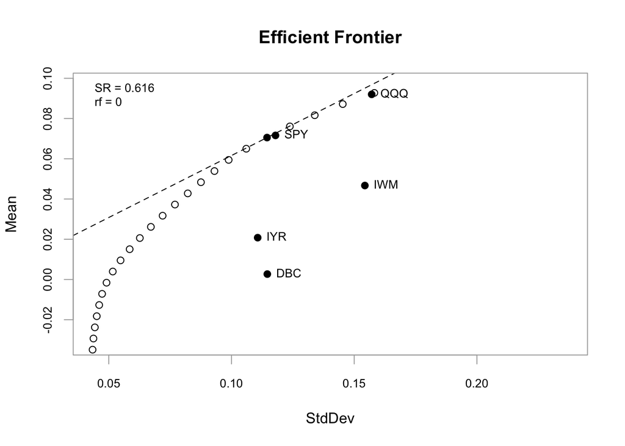

```r
library(PortfolioAnalytics)
  returns <- stock_returns
#  define moment function
  annualized.moments <- function(R, scale=12, portfolio=NULL){
    out <- list()
    out$mu <-    matrix(colMeans(R), ncol=1)
    out$sigma <- cov(R)/scale
    return(out)
  }
# define portfolio
  prt <- portfolio.spec(assets=colnames(stock_returns))
  prt <- add.constraint(portfolio=prt, type="long_only")
  #  leverage defaults to weight_sum = 1 so is equivalent to full_investment constraint
  prt <- add.constraint(portfolio=prt, type="leverage")
  prt <- add.objective(portfolio=prt, type="risk", name="StdDev")
# calculate and plot efficient frontier
  prt_ef <- create.EfficientFrontier(R=12*stock_returns, portfolio=prt, type="mean-StdDev",
                                      match.col = "StdDev", momentFUN="annualized.moments", scale=12)
  xlim <- range(prt_ef$frontier[,2])*c(1, 1.5)
  ylim <- range(prt_ef$frontier[,1])*c(.80, 1.05)
  chart.EfficientFrontier(prt_ef, match.col="StdDev", chart.assets = FALSE,
                          labels.assets = FALSE, xlim=xlim, ylim=ylim )
  points(with(annualized.moments(12*stock_returns, scale=12), cbind(sqrt(diag(sigma)), mu)), pch=19 )
  text(with(annualized.moments(12*stock_returns, scale=12), cbind(sqrt(diag(sigma)), mu)),
       labels=colnames(returns), cex=.8, pos=4)
```

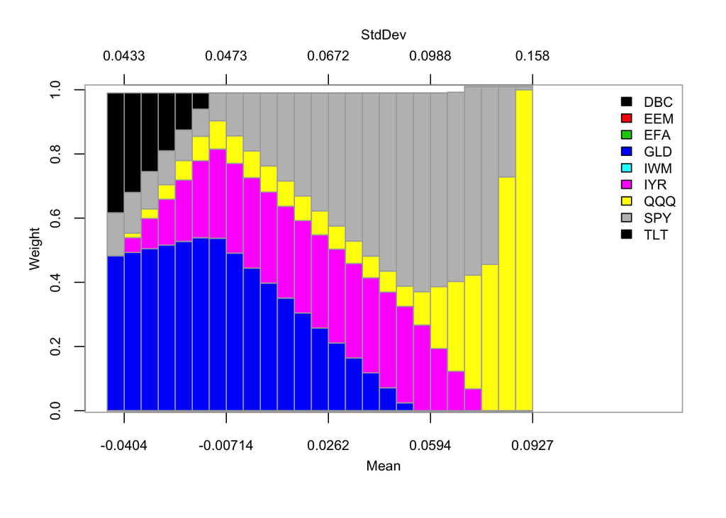

```r
  chart.EF.Weights(prt_ef, match.col="StdDev")
```

## 10.3 [Second EF Example from Stack Overflow](https://stackoverflow.com/questions/30614457/r-portfolio-analytics-chart-efficientfrontier-function/30650972#30650972)

```r
require(quadprog)
#min_x(-d^T x + 1/2 b^T D x) r.t A.x>=b
MV_QP<-function(nx, tarRet, Sig=NULL,long_only=FALSE){
  if (is.null(Sig)) Sig=cov(nx)
  dvec=rep(0,ncol(Sig))
  meq=2
  Amat=rbind(rep(1,ncol(Sig)),
             apply(nx,2,mean) )
  bvec=c(1,tarRet )
  if (long_only) {
    meq=1
    Amat=Amat[-1,]
    Amat=rbind(Amat,
               diag(1,ncol(Sig)),
               rep(1,ncol(Sig)),
               rep(-1,ncol(Sig)))
    bvec=bvec[-1]
    bvec=c(bvec,
               rep(0,ncol(Sig)),.98,-1.02)
  }
  sol  <- solve.QP(Dmat=Sig, dvec, t(Amat), bvec, meq=meq)$solution
}

steps=50
x=returns
 µ.b <- apply(X = x, 2, FUN = mean)
long_only=TRUE
range.bl <- seq(from = min(µ.b), to = max(µ.b)*ifelse(long_only,1,1.6), length.out = steps)
risk.bl <- t(sapply(range.bl, function(targetReturn) {
  w <- MV_QP(x, targetReturn,long_only=long_only)
  c(sd(x %*% w),w)  }))

weigthsl=round(risk.bl[,-1],4)
colnames(weigthsl)=colnames(x)
weigthsl %>% head()
```

```
 DBC    EEM EFA    GLD IWM IYR QQQ SPY    TLT
```

[1,] 0 0.9395 0 0.0000 0 0 0 0 0.0805 [2,] 0 0.7745 0 0.0000 0 0 0 0 0.2455 [3,] 0 0.6096 0 0.0000 0 0 0 0 0.4104 [4,] 0 0.4446 0 0.0000 0 0 0 0 0.5754 [5,] 0 0.3022 0 0.0285 0 0 0 0 0.6893 [6,] 0 0.2305 0 0.1466 0 0 0 0 0.6429

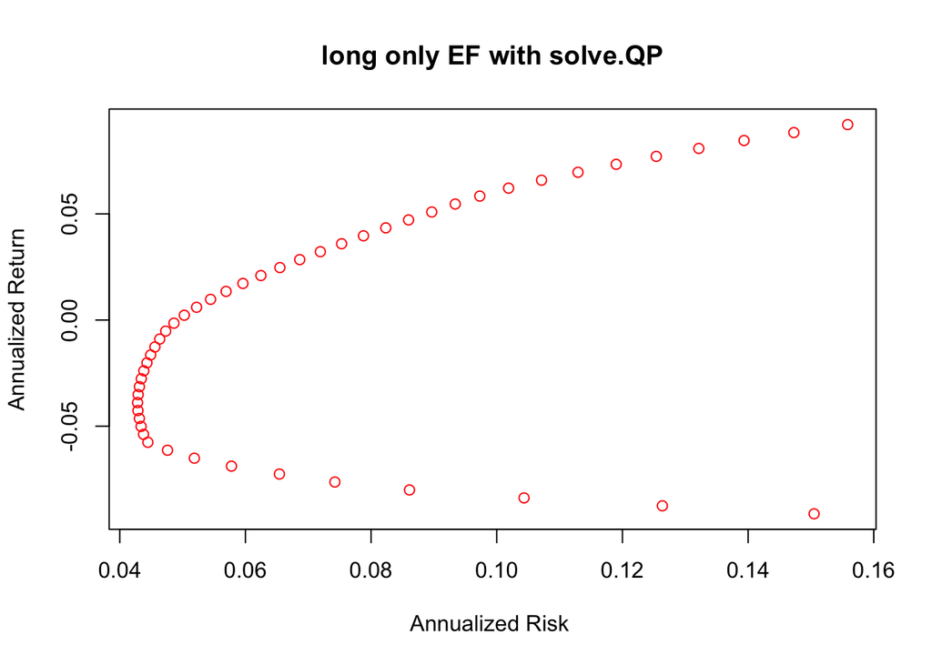

```r
risk.bl=risk.bl[,1]
rets.bl= weigthsl%*%µ.b
fan=12
plot(x = risk.bl*fan^.5, y = rets.bl*fan,col=2,pch=21,
     xlab = "Annualized Risk ",
     ylab = "Annualized Return", main = "long only EF with solve.QP")
```

```r
# demo(multi_layer_optimization)
```